# 52-naive-bayes-performance

In this notebook we explore the performance of the Naive Bayes model. Additionally, we will confirm the behavior of cross validation and hyperparameter tuning.

**Make sure you run the 42-naivebayes-modeling notebook before attempting to run this notebook to generate new results**

# 1 Load Saved Data

```r
move_model_info('nb', 'load')
```

# 2 Selected Model Performance Evaluation

## 2.1 Cross validation metrics from best model

Let’s first evaluate the performance using the cross-validation metrics from before. However, here, we’ll only look at the best model.

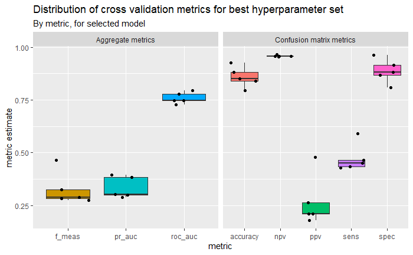

```r
#get best nb metrics
best_nb_fold_metrics <- calculate_best_performance_metrics(nb_fold_metrics, best_nb_params)
```

```r
best_nb_fold_metrics %>%
  group_by(.metric) %>%
  summarize(overall_perf = mean(.estimate))
```

|  | .metric | overall_perf |
| --- | --- | --- |
| 1 | accuracy | 0.8592538 |
| 2 | f_meas | 0.3278430 |
| 3 | npv | 0.9585575 |
| 4 | ppv | 0.2685933 |
| 5 | pr_auc | 0.3335970 |
| 6 | roc_auc | 0.7593557 |
| 7 | sens | 0.4739606 |
| 8 | spec | 0.8875348 |

```r
NA
```

We see very high values for accuracy, npv, and spec, all of which point to this model being one of the “outliers” we discussed earlier.

## 2.2 Performance on training data as a whole

Here, we look at the confusion matrix for the entire training set as well as computations from the confusion matrix.

[output not shown]

[output cut: 46 more lines]

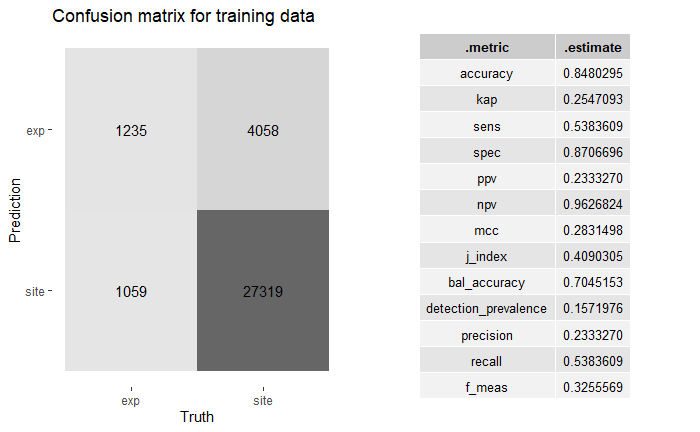

```r
#get prediction class and probabilities
nb_training_preds <- get_prediction_dataframes(nb_final_fit, train_data)

#plot and calculate confusion matrix
calculate_confusion_matrix(nb_training_preds)
```

# 3 Explaining the model

## 3.1 Variable imporance

What parameters are contributing most strongly to the classification? Do we see evidence of data snooping? Let’s take a look!

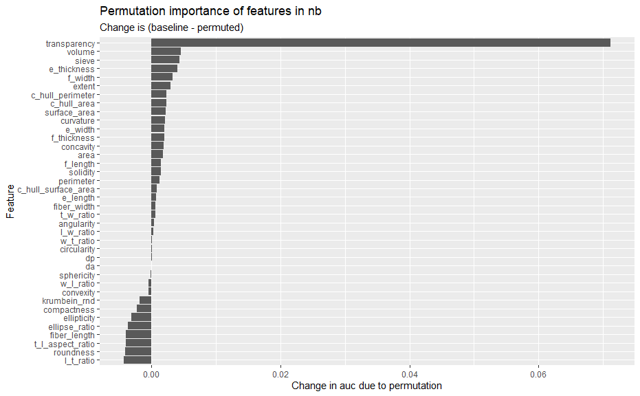

```r
nb_vip <- plot_variable_importance(nb_final_fit, assessment_data=train_data, mdl_name = 'nb', positive_class='exp')
```

## 3.2 ROC curves

```
    === AUCs ===

     Model name Dataset ID Curve type       AUC
   1     Model1          1        ROC 0.7812023
   2     Model1          1        PRC 0.4041006

    === Input data ===

     Model name Dataset ID # of negatives # of positives
   1     Model1          1          31377           2294
```

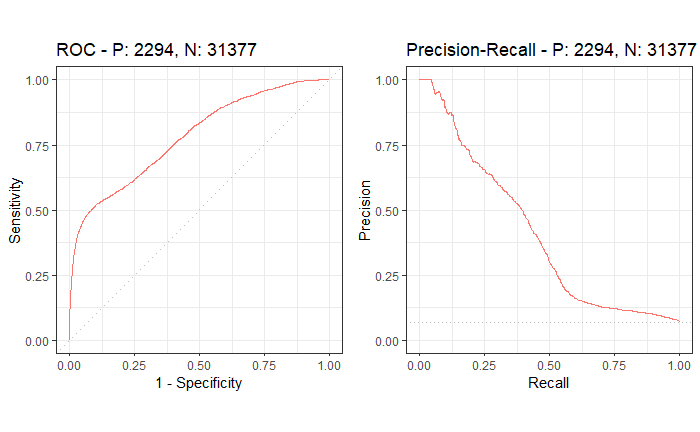

```r
plot_performance_curves(nb_training_preds)
```

These curves demonstrate sub-optimal performance, particularly in comparison with the performance of other models. This will likely not be the best model to use for prediction.

##Calibration curve

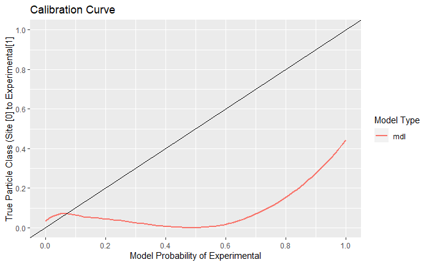

```r
#get prediction class and probabilities
plot_calibration_curve(nb_training_preds)
```

The calibration curve is abysmal, and thus we can conclude that the scores generated from the model in no way reflect true probabilities. If this model is desired to be used (probably not in the context of the other models), and the scores are desired to be used as probabilities, extra calibration must be done on this model to adjust the scores appropriately.

##Threshold for particles

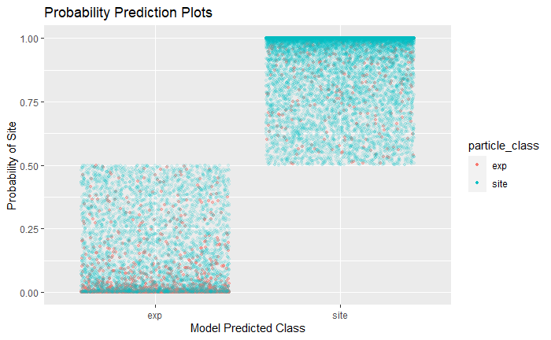

```r
#get prediction class and probabilities
plot_prediction_probabilities(nb_training_preds)
```

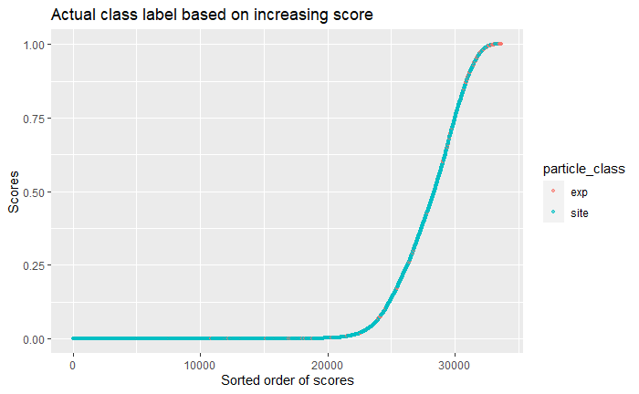

```r
plot_label_by_score(nb_training_preds)
```

This model does not appear to have a very strong threshold, particularly at the default threshold of 0.5. This is relatively reflected in the ROC curve, where better performance is achieved in a very specific corner of the ROC curve. This model, if used, would additionally require a specifically identified threshold, as 0.5 does not appear here to show a strong delineation threshold. The threshold actually appears to be closer to around 0.8. This conclusion is also substantiated by the calibration curve, which suggests that the model likes to predict higher scores - or if considered probabilities - than they actually should be.

# 4 Save markdown file

```r
fs::file_copy('52-naive-bayes-performance.nb.html', './html_results/52-naive-bayes-performance.nb.html', overwrite=TRUE)
```